# OA3802 Lab 1: Bash + regex

[figure not shown]

### Introduction

In this lab, you will apply numerous concepts introduced this past week in OA3802. More specifically, you will expand your command line interface skills by executing some basic `bash` commands to acquire and analyze data files from a public web source. Additionally, you will perform basic `regex` operations to answer specific questions about the acquired data using your choice of programming language (*limited to* `r`, `python` or `bash`). The primary goal of this assignment is beyond just developing the required ‘code’ to execute the assigned tasks. You should focus on documenting all actions and decisions taken with the ultimate goal of producing a tutorial in `html` format that provides a reproducible artifact for others (and your future self) to reference.

### Lab Scenario

You are currently serving as an OR analyst tasked with analyzing global maritime traffic. The recent efforts to make Automatic Identification System (AIS) transponder data publicly available has led to it serving as your primary data source for your analysis tasks. The digital exhaust created by AIS meets the threshold of ‘big data’ given the particular volume and velocity associated with it. To read more about AIS, please visit the following site [(link)](https://en.wikipedia.org/wiki/Automatic_identification_system#Viewing_and_using_AIS_data) prior to moving on to the Tasks section.

### Tasks

#### Task 1: Acquire AIS Data (15 points)

AIS is made public by numerous agencies/entities. We will focus on the most recent offering provided by the U.S. Coast Guard and NOAA [(AIS Data 2018)](https://coast.noaa.gov/htdata/CMSP/AISDataHandler/2018/index.html) that accounts for AIS data from 2018. Notice at the landing page (depicted below) that we are provided with direct access to monthly files and instructions on how to use the `bash` command `wget` to retrieve **ALL OF** the files. (NOTE: do not pull all of the files!! – SEE BELOW IMAGE for specific task)

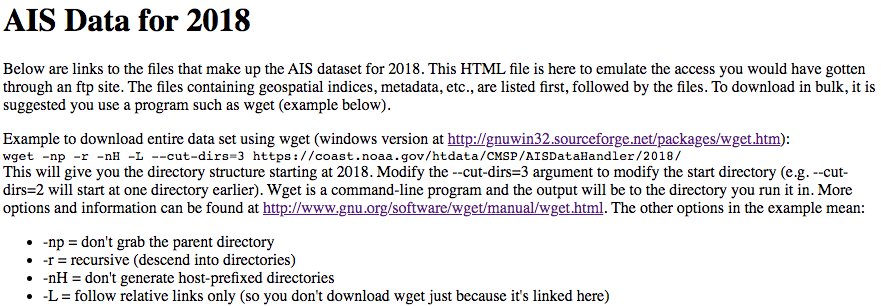

To complete **Task 1** use `wget` to retrieve the daily AIS files: `AIS_2018_01_01.zip` and `AIS_2018_04_01.zip`  
Please display the `bash` code you write to accomplish this task within your final tutorial document. An example would be as such:

```bash
wget -i AIS.txt
```

I created a text file with the appropriate AIS hyperlinks.  
* https://coast.noaa.gov/htdata/CMSP/AISDataHandler/2018/AIS_2018_01_01.zip  
* https://coast.noaa.gov/htdata/CMSP/AISDataHandler/2018/AIS_2018_04_01.zip

#### Task 2: Assess newly acquired files (20 points)

You have now sucessfully downloaded two large `.zip` files containing AIS data for the days of concern (i.e. 1Jan18, 1Apr18). We know that these files are compressed, but we do not know what is contained in them in terms of number of files or the size of these uncompressed files. So, without decompressing/inflating the files, take advantage of the `bash` command `unzip` to view and report metadata details about each daily file. Also, ‘peek’ into the files and show the first 10 rows of each respective daily file. Again, display your code to accomplish these tasks and provide a summary narrative of the results.

```bash
unzip -c AIS_2018_01_01.zip | head -10
unzip -c AIS_2018_04_01.zip | head -10

unzip -l AIS_2018_01_01.zip  # The -l allows me to look akt the meta data
unzip -l AIS_2018_04_01.zip
```

[output not shown]

#### Task 3: Decompress file of focus via `bash` (10 points)

We have decided that our primary focus day will be `1Apr18`. Therefore, we need to unzip the file to make it available for deeper analysis. We previously checked the metadata of the file and feel confident that our local system can account for the inflating size of the decompressed file. Show the `bash` code required to `unzip` this file:

```bash
unzip AIS_2018_04_01.zip
```

#### Task 4: Using `regex` to parse country-level activity from the MMSI field (30 points)

An AIS transmission consists of 17 columns, but the MMSI is the most important field. The Maritime Mobile Service Identity (MMSI) is a unique nine digit identifier to identify a ship or a coast radio station. The MMSI follows an explicit naming convention that allows us to ascertain great detail about each indentifier. To see the standard format, view the `MMSI_Format_Overview.pdf` document provided in the lab zip file or access a version directly at the following [website](https://www.navcen.uscg.gov/?pageName=mtmmsi#). Of particular interest, we see that the first three characters of an individual **ship’s** MMSI signifies the Maritime Identification Digits (MID). The MID is the national entity responsible for issuing/managing the MMSI for that particular ship. You can access a lookup table for all MID values [here](https://en.wikipedia.org/wiki/Maritime_identification_digits). For example, an MMSI of `503123456` would signify a ship associated with Australia. We will assume the MID to be a direct proxy of a ship’s national origin.

For Task 4, you will **determine the total unique vessel count of ships that have a national origin from the following nations: Canada, Singapore, and Cayman Islands.** To accomplish this task, you will use some form of `regex` operations in the programming language of your choice (i.e. `python`, `r` or `bash`). Present the code to accomplish the task and a narrative describing your methods and results.

MMSI Codes * Canada - 316 * Singapore - 563, 564, 565, 566 * Cayman Islands - 319

```r
# Reading in data
AIS_2018 <- read.csv("AIS_2018_04_01.csv")
# head(AIS_2018,25)
# tail(AIS_2018,25)
# dim(AIS_2018)
# str(AIS_2018)
```

```r
tot_vess <- length(AIS_2018[grep("^316|^563|^564|^565|^566|^319",AIS_2018$MMSI),"MMSI"])
tot_uni.vess <- length(unique(AIS_2018[grep("^316|^563|^564|^565|^566|^319",AIS_2018$MMSI),"MMSI"]))

print(paste("Out of the", tot_vess, "vessels associated with Canada, Singapore, and the Cayman Islands, there are only",  tot_uni.vess, "unique vessels"))
```

```
## [1] "Out of the 334602 vessels associated with Canada, Singapore, and the Cayman Islands, there are only 1014 unique vessels"
```

Methodology * Reading in the Data + This was probably the easiest part. + I used a read.csv and verified that the data was read in correctly utilizing the head and tail functions. + After I read in the data, I had to identify which MMSI correlated to Canada, Singapore, and the Cayman Islands.

- Regular Expressions
- Trying to find to find a pattern that correctly identified the correct MMSI was the most complicated part of this exercise.
- I initially tried using, (grep (316, AIS_2018$MMSI)), but then I realized that 316 was being pulled from the entire MMSI and just the first 3 digits. That is when I stumbled upon the “^” operator. This tells grep to only look for 316 at the start of each expression.
- After I got the pattern everything else was simple enough. I used R’s vectorization in convert with the grep function to find all the unique values associated with Canada, Singapore, and the Cayman Islands.

#### Task 5: What if we had to conduct this analysis over an entire month (or even a year) on our local computing system? (25 points)

For this final task, I want you to provide a narrative response to how you would tackle this problem if you had to scale to a greater timeframe such as a month or a year. We know we would eventually run out of memory quite fast since each daily file decompresses to almost 1GB. Therefore, please describe some potential methods you could incorporate to reduce the memory burden and still be able to provide a rolling count of the three countries evaluated in Task 4. I do not expect you to write and execute any code, but if you think pseudocode or diagrams would help explain your process, please include those.

- Steps:
1. Identify where I want to store the information. In order to prevent overlaoding my local drive I would store the information in some kind of cloud data base.
2. Figure out how much of the data I need to grap. Ex: Year, month, specific days
3. Construct a R function that generates a new text file with the names/ hyperlinks for the respective desired zips.
4. Use Bash to upload text zips into the cloud.
5. Use Bash and a for-loop to unzip files in the cloud.
6. Use one for-loop to do the following:
- Create an empty list to hold the unique vassel count and appropriate title
- Bring files into my R enviornment. (Storing only one file at a time)
- Count unique vessels for the three countries
- Append the count to the list.
- Also ensure that the year, month, and day (as appropriate) are tied to the unqiue values in some kind of print statement.

## Coordinating Instructions

You will complete this assignment on you personal computer. This is deliberate in that we want to become familiar with the limitations of a local system (specifically your own) and better understand how to tackle ‘larger’ data problems in a constrained environment.

The final **25 points** associated with this lab assignment are reserved for correctness and clarity provided via your `html` tutorial product and any additional code files submitted.

The final submission is due next Tuesday evening NLT 2300 via the Assignments tab on the course Sakai site. Please submit your completed `html` file as well as any supplementary code files.